# Dzietność kobiet w latach 2003/2018 na świecie

TP

12/12/2019

## Współczynnik dzietności (fertility rate)

Współczynnik określający liczbę urodzonych dzieci przypadających na jedną kobietę w wieku rozrodczym (15–49 lat). Przyjmuje się, iż FR między 2,10–2,15 zapewnia zastępowalność pokoleń.

Plik `fertility_rate_2003_2018.csv` pobrany ze strony https://ourworldindata.org/grapher/fertility-rate-complete-gapminder zawiera wartości współczynnika w roku 2003 oraz 2018 (czyli po 15 latach)

Plik nie zawiera kodów dla krajów: Slovakia Micronesia, Timor, Channel Islands. Za to zawiera pozycję zbiorczą pn World (usunięta). Ponieważ nie ustalono kodu dla Channel Islands to tę pozycję też usunięto, bo to mały kraj jest (konkretnie dwa wiesze: `Channel Islands;OWID_CIS;2003;1.41` oraz `Channel Islands;OWID_CIS;2018;1.49`). Pozostałe braki uzupełniono.

## Porównanie wartości współczynnika dzietności

W roku 2003 wartość minimalna, mediana i maksymalna wynosiły odpowiednio: 0.83, 2.59 oraz 7.64. Średnia wynosiła zaś 3.1190594. W roku 2018 wartość minimalna, mediana i maksymalna wynosiły odpowiednio: 1.22, 2.2 oraz 7.13 Średnia wynosiła zaś 2.6778607 (co oznacza spadek o 0.4411987 dziecka/kobietę.)

Liczba krajów o wartości współczynnika mniejszej niż 2,1 (tj. nie gwarantującej zastępowalności pokoleń) wynosiła 76 w roku 2003 oraz 94 w roku 2018 (albo odpowiednio 37.6% oraz 46.8% krajów).

## Porównanie rozkładu współczynnika dzietności

Do oceny rozkładu wartości zmiennej służy histogram. Jeżeli umieścimy obok siebie dwa histogramy, możemy w ten sposób porównać (wizualnie) dwa rozkłady:

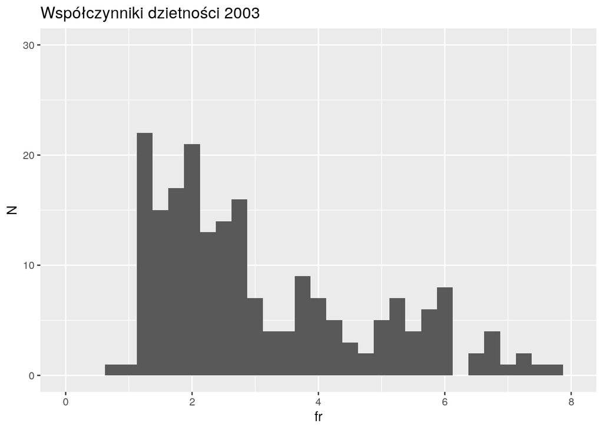

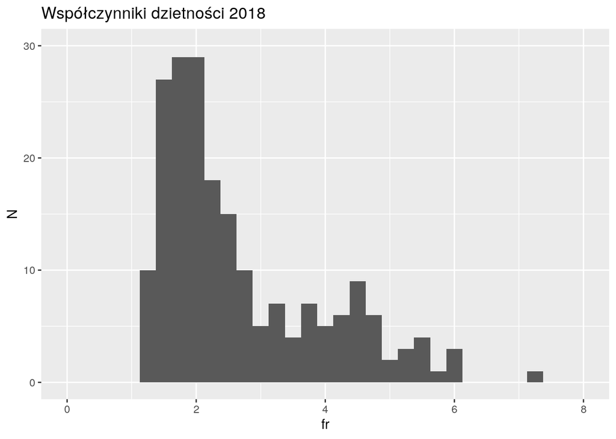

Aby porównanie było łatwiejsze warto zadbać o jednakowe wartości na osiach XY.Patrząc na wykres widać wyraźnie że przybyło krajów o wartości współczynnika około 2 a ubyło o dużych wartości.

Do tego samego celu (porównania) można też wykorzystać wykres punktowy (jak ktoś umie go zrobić):

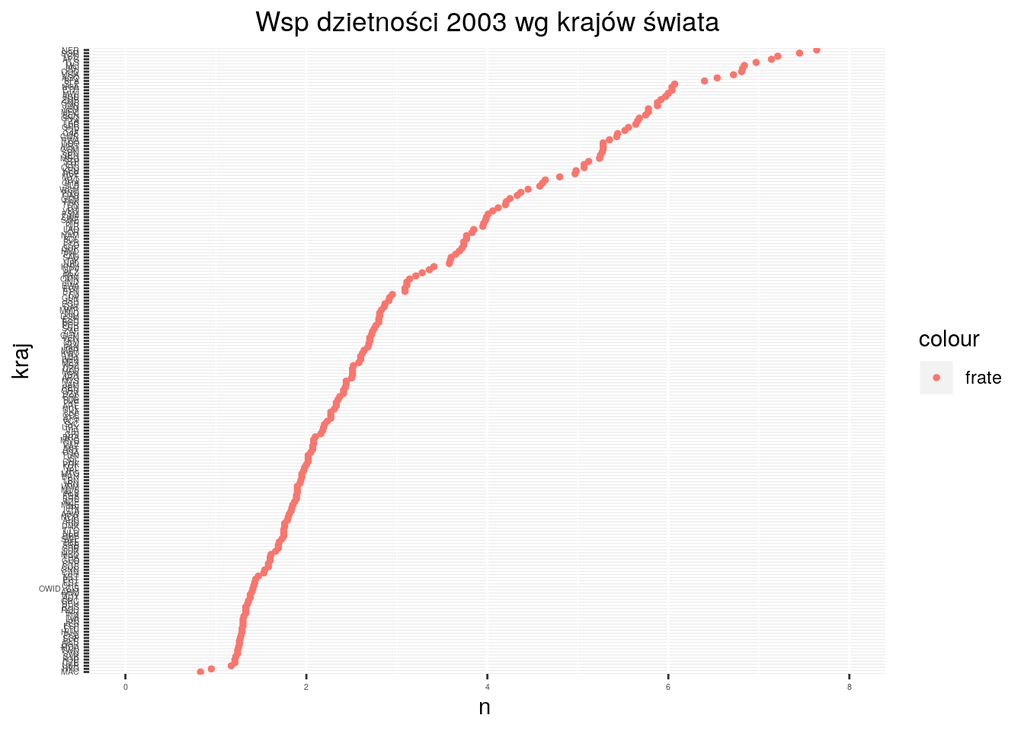

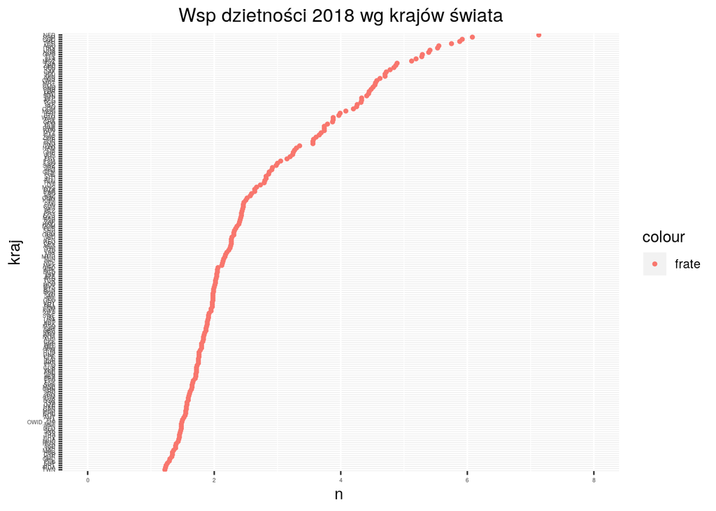

## Porównanie na jednym wykresie

Łącznie na jednym wykresie (histogram/wykres częstości aka *frequency distribution*):

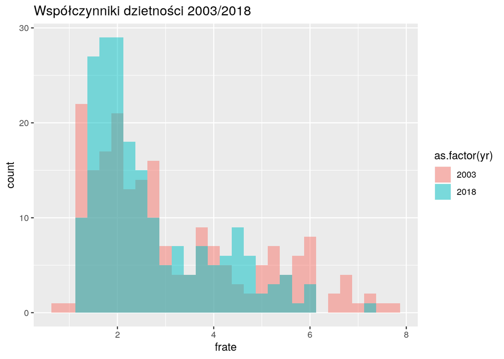

```r
ggplot(dA, aes(x=frate, fill=as.factor(yr))) +
  ggtitle("Współczynniki dzietności 2003/2018") +
  geom_histogram(binwidth=0.25, alpha=.5, position="identity")
```

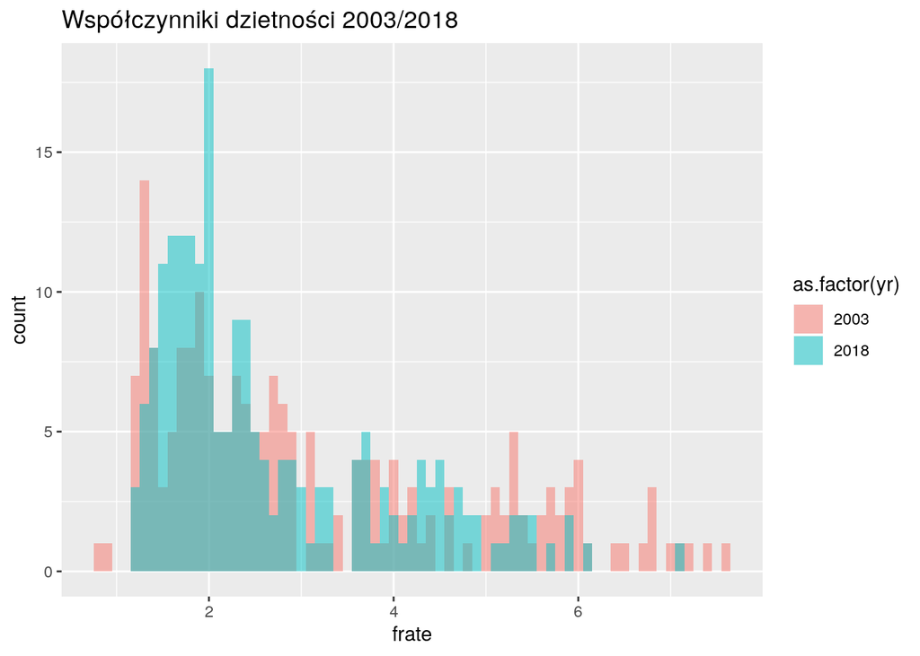

```r
ggplot(dA, aes(x=frate, fill=as.factor(yr))) +
  ggtitle("Współczynniki dzietności 2003/2018") +
  geom_histogram(binwidth=0.1, alpha=.5, position="identity")
```

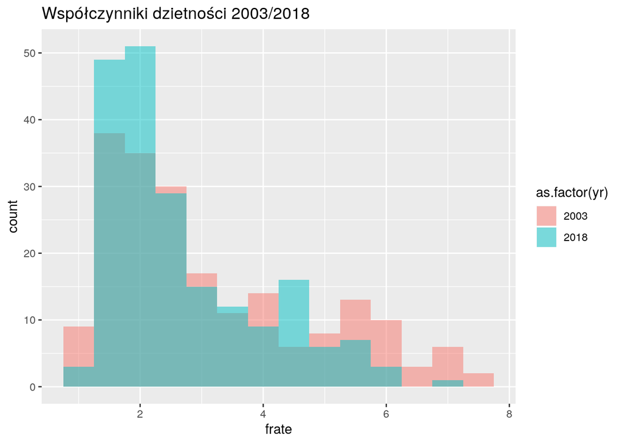

```r
ggplot(dA, aes(x=frate, fill=as.factor(yr))) +
  ggtitle("Współczynniki dzietności 2003/2018") +
  geom_histogram(binwidth=0.5, alpha=.5, position="identity")
```

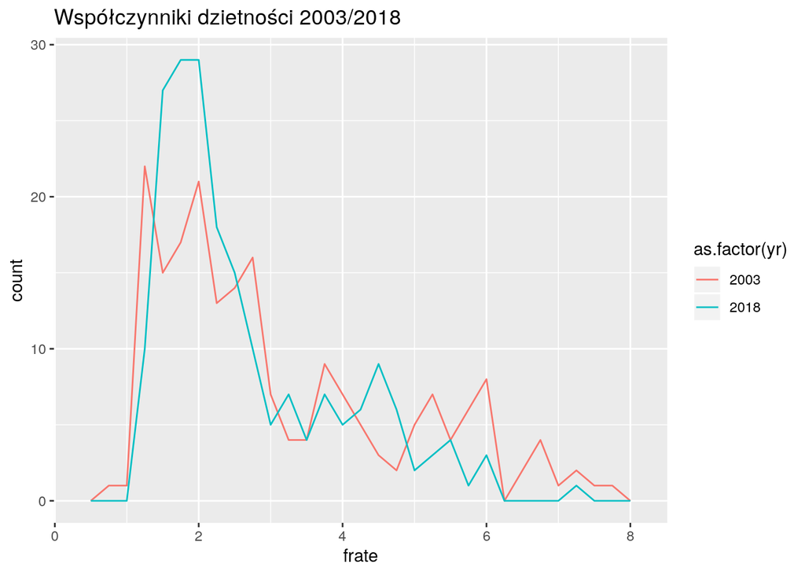

```r
### freq_polys

ggplot(dA, aes(x= frate, colour = as.factor(yr))) +
  ggtitle("Współczynniki dzietności 2003/2018") +
  geom_freqpoly(binwidth = 0.25)
```

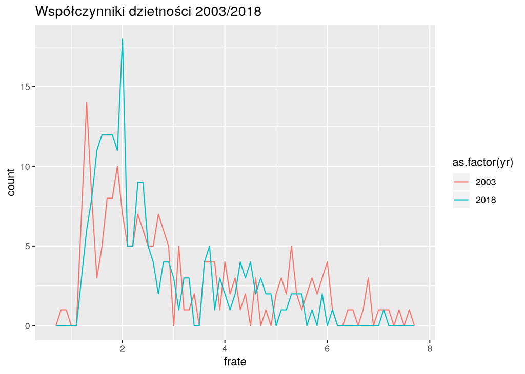

```r
ggplot(dA, aes(x= frate, colour = as.factor(yr))) +
  ggtitle("Współczynniki dzietności 2003/2018") +
  geom_freqpoly(binwidth = 0.1)
```

Łącznie na jednym wykresie (wykres pudełkowy):

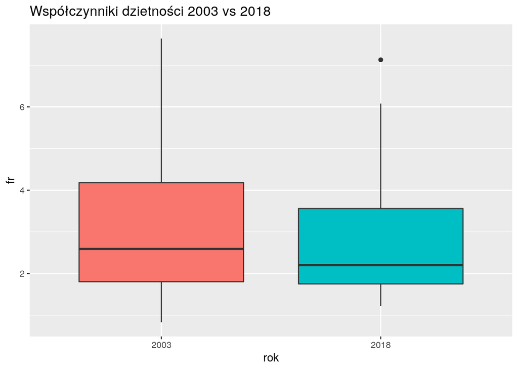

```r
ggplot(dA, aes(x=as.factor(yr), y=frate, fill=as.factor(yr))) + geom_boxplot() +
 ylab("fr") +
 xlab("rok") +
 ggtitle("Współczynniki dzietności 2003 vs 2018") +
 theme(legend.position="none")
```

Łącznie na jednym wykresie (wykres punktowy):

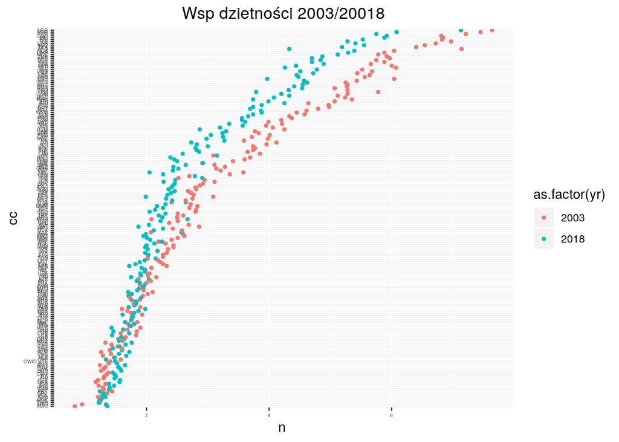

```r
ggplot(dA, aes(x = reorder(symbol, frate) )) +
  geom_point(aes(y = frate, colour = as.factor(yr) ), size=1) +
  xlab(label="cc") + ylab(label="n ") + coord_flip()+
  ggtitle("Wsp dzietności 2003/20018") +
  theme(axis.text = element_text(size = 4)) +
  theme(plot.title = element_text(hjust = 0.5)) +
  coord_cartesian(ylim = c(0, 8)) +
  coord_flip()
```

## Wykresy punktowe w podziale na kontynenty

Do podziału na kontynenty potrzebna jest oczywiście informacja na jakim kontynencie znajduje się konkretny kraj (Rosja na przykład :-)) Informację tę w postaci stosownego pliku CSV pobieram ze strony: https://datahub.io/JohnSnowLabs/country-and-continent-codes-list. A następnie scalamy z plikiem `fertility_rate_2003_2018.csv` (w sumie to moglibyśmy od razu działać na pliku *scalonym* ale wtedy nie do końca byłoby jasne skąd on się wziął. Tak mamy jasność: dane dot dzietności pobrani *stąd-a-stąd*, a dane dot. klasyfikacji krajów *skądinąd*.)

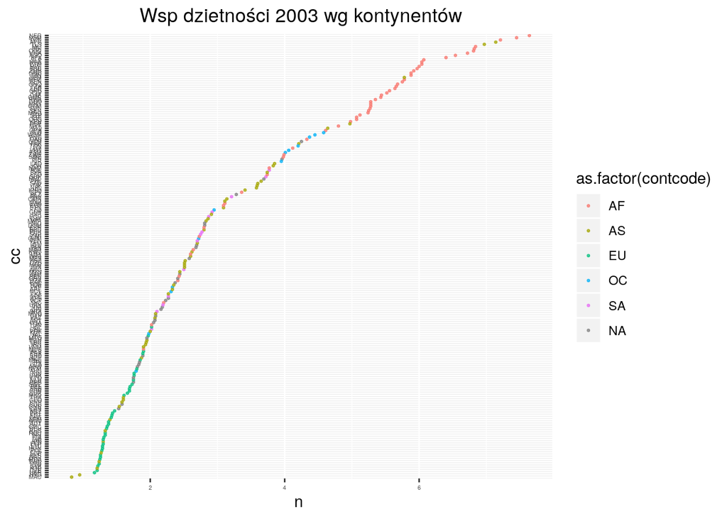

```r
dA <- read.csv("fertility_rate_2003_2018cc.csv", sep = ';',  header=T, na.string="NA");
d2003 <- dA %>% filter(yr==2003) %>% as.data.frame
d2018 <- dA %>% filter(yr==2018) %>% as.data.frame

ggplot(d2003, aes(x = reorder(symbol, frate) )) +
  geom_point(aes(y = frate, colour = as.factor(contcode) ), size=.5, alpha=.7) +
  xlab(label="cc") + ylab(label="n ") + coord_flip()+
  ggtitle("Wsp dzietności 2003 wg kontynentów") +
  theme(axis.text = element_text(size = 4)) +
  theme(plot.title = element_text(hjust = 0.5)) +
  coord_cartesian(ylim = c(0, 8)) +
  coord_flip()
```

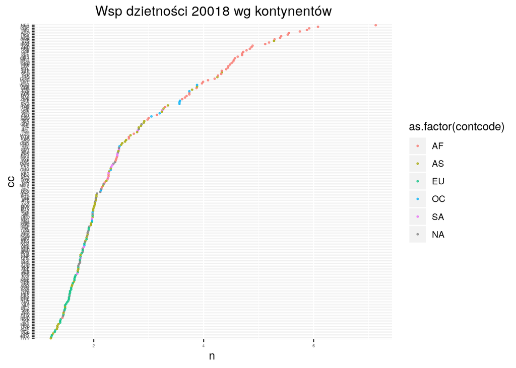

```r
ggplot(d2018, aes(x = reorder(symbol, frate) )) +
  geom_point(aes(y = frate, colour = as.factor(contcode) ), size=.5, alpha=.7) +
  xlab(label="cc") + ylab(label="n ") + coord_flip()+
  ggtitle("Wsp dzietności 20018 wg kontynentów") +
  theme(axis.text = element_text(size = 4)) +
  theme(plot.title = element_text(hjust = 0.5)) +
  coord_cartesian(ylim = c(0, 8)) +
  coord_flip()
```

Afryka dominuje jak widać, Europa na końcu…